# Data Exploration and Report Generation

Data exploration is a crucial step in the data analysis process to understand the structure, patterns, and characteristics of datasets. This Jupyter notebook explores the dataset of the project and gains valuable insights. Here's an outline of the structure of this data exploration notebook:

1. Introduction and motivation: A brief overview of the project and the dataset.
2. Install Dependencies: Install the required dependencies.
3. Methods: ETL pipeline building and Problems encountered
4. Import Packages: Import the necessary packages.
5. Data Loading: Load the data into a notebook.
6. Data Inspection : Explore the dataset for basic understanding.
7. Data Visualization: Create visualizations to explore the data and gain insights.
8. Correlation Analysis: Analyze the correlation between data, summary of the plots
9. Conclusion: Summarize the key findings and insights obtained from the data exploration.
10. Limitations and Future works

# 1.Introduction & Motivation:

**Exploring the Correlation Between Unemployment and Crime Rates in G7 Nations and India Over Two Decades (2000-2020)**

The choice to focus on the G7 countries, and India offers a diverse representation of economic structures, cultural contexts, and governance models. By scrutinizing these distinct entities, we aim to draw nuanced insights that transcend regional boundaries and contribute to a more global understanding of the relationship between unemployment and crime.

Through the lens of statistical analysis, this project seeks to unravel patterns and trends, identifying potential correlations that can guide evidence-based policymaking. The implications of such findings could extend to the formulation of targeted interventions, social programs, and economic policies aimed at mitigating both unemployment and crime. This research endeavor aligns with the broader goal of fostering societal well-being by providing stakeholders with valuable insights into the interconnected dynamics of unemployment and crime rates over time.

Moreover, as technological advancements and globalization reshape the economic landscape, it becomes increasingly pertinent to reevaluate established notions and adapt strategies to address emerging challenges. The temporal scope of our analysis, spanning several decades, allows us to observe trends in the context of evolving socio-economic conditions, providing a historical perspective to contemporary discussions on unemployment and crime.

# 2. Install dependencies

Install the dependencies that are required in the exploration.

```python
%pip install pandas
%pip install matplotlib
%pip install seaborn
```

# 3. Methods

**1. About Dataset**

**2. How you built your data pipeline ?**

Given the project's need for two distinct datasets, I made an ETL (Extract, Transform, Load) pipeline which initiates with data extraction from its original source, transforming the data according to our need and then cultimates by storing the processed data in a CSV file for further expploration

**Problems encountered :**

The ETL pipeline encountered challenges, during extraction , the code was extracting zip file so have to write a read code to open the csv file inside the zip folder. In the transformation phase. The crime dataset posed difficulties with numerous countries having either empty or extensively null values. To address this, a meticulous approach was adopted to handle missing data, ensuring a comprehensive and reliable dataset for analysis.

Despite these challenges, the ETL pipeline stands as a crucial component, facilitating the systematic processing of raw data into a refined and standardized format ready for in-depth exploration of the correlation between unemployment and crime across selected countries and over the years.

# 4.Import Packages

Import the necessary packages that will be used in the exploration

```python
import os
import pandas as pd
import numpy as np
import matplotlib.pyplot as plt
import seaborn as sns
from datetime import datetime as dtime
```

# 5.Data Loading

Load the transformed csv data file into the notebook using pandas.

```python
unemployment_df = pd.read_csv('data/unemployment.csv')
crime_df = pd.read_csv('data/crime.csv')
```

# 6.Data Inspection

Most of the pre-processing work has already been completed in the transformation stage of the automated ETL pipeline. In Inspection Stage we will i)Explore the dataset by examining its structure, dimensions, and basic properties to get an initial understanding of the data.

Let's start with unemployment dataset

unemployment Dataset: Get insights from the unemployment dataset that is obtained after ETL process.

```python
unemployment_df.head(10)
```

|  | Country Name | 1991 | 1992 | 1993 | 1994 | 1995 | 1996 | 1997 | 1998 | 1999 | ... | 2012 | 2013 | 2014 | 2015 | 2016 | 2017 | 2018 | 2019 | 2020 | 2021 |
| --- | --- | --- | --- | --- | --- | --- | --- | --- | --- | --- | --- | --- | --- | --- | --- | --- | --- | --- | --- | --- | --- |
| 0 | Albania | 10.307 | 30.015 | 25.258 | 20.840 | 14.611 | 13.931 | 16.876 | 20.047 | 20.840 | ... | 13.380 | 15.870 | 18.050 | 17.190 | 15.420 | 13.620 | 12.30 | 11.470 | 13.067 | 12.683 |
| 1 | Armenia | 1.600 | 1.800 | 5.300 | 6.600 | 6.700 | 9.300 | 10.800 | 9.400 | 11.200 | ... | 11.298 | 11.531 | 11.862 | 12.177 | 12.426 | 12.944 | 13.21 | 12.200 | 12.180 | 12.729 |
| 2 | Australia | 9.580 | 10.730 | 10.870 | 9.720 | 8.470 | 8.510 | 8.360 | 7.680 | 6.870 | ... | 5.220 | 5.660 | 6.080 | 6.050 | 5.710 | 5.590 | 5.30 | 5.160 | 6.460 | 5.120 |
| 3 | Austria | 3.420 | 3.590 | 4.250 | 3.540 | 4.340 | 5.280 | 5.150 | 5.480 | 4.700 | ... | 4.870 | 5.340 | 5.620 | 5.720 | 6.010 | 5.500 | 4.85 | 4.490 | 5.360 | 6.180 |
| 4 | Azerbaijan | 0.900 | 1.800 | 4.500 | 6.300 | 7.200 | 8.100 | 9.100 | 10.000 | 10.900 | ... | 5.190 | 4.970 | 4.910 | 4.960 | 5.000 | 4.960 | 4.94 | 4.850 | 7.160 | 5.950 |
| 5 | Benin | 1.484 | 1.510 | 1.396 | 1.358 | 1.237 | 1.175 | 1.083 | 1.018 | 0.927 | ... | 2.454 | 2.254 | 2.111 | 2.023 | 1.836 | 1.643 | 1.47 | 1.466 | 1.671 | 1.752 |
| 6 | Bulgaria | 11.100 | 15.300 | 16.400 | 12.800 | 11.100 | 12.500 | 13.700 | 12.200 | 14.100 | ... | 12.270 | 12.940 | 11.420 | 9.140 | 7.570 | 6.160 | 5.21 | 4.230 | 5.120 | 5.270 |
| 7 | Bahamas, The | 12.170 | 14.810 | 12.720 | 13.830 | 10.830 | 11.460 | 9.760 | 7.650 | 7.450 | ... | 14.020 | 16.180 | 13.800 | 12.000 | 12.700 | 9.800 | 10.00 | 10.051 | 12.867 | 11.665 |
| 8 | Brazil | 6.366 | 6.420 | 6.030 | 6.470 | 7.090 | 8.030 | 9.000 | 10.150 | 11.130 | ... | 7.250 | 7.070 | 6.760 | 8.560 | 11.740 | 12.930 | 12.46 | 12.050 | 13.930 | 13.340 |
| 9 | Barbados | 22.683 | 22.940 | 24.540 | 22.980 | 19.660 | 14.710 | 14.610 | 12.400 | 10.610 | ... | 11.590 | 11.550 | 12.170 | 9.800 | 8.250 | 8.620 | 8.32 | 8.410 | 10.105 | 9.582 |

10 rows × 32 columns

```python
unemployment_df.shape
```

```
(100, 32)
```

```python
unemployment_df.info()
```

```
<class 'pandas.core.frame.DataFrame'>
RangeIndex: 100 entries, 0 to 99
Data columns (total 32 columns):
 #   Column        Non-Null Count  Dtype
---  ------        --------------  -----
 0   Country Name  100 non-null    object
 1   1991          100 non-null    float64
 2   1992          100 non-null    float64
 3   1993          100 non-null    float64
 4   1994          100 non-null    float64
 5   1995          100 non-null    float64
 6   1996          100 non-null    float64
 7   1997          100 non-null    float64
 8   1998          100 non-null    float64
 9   1999          100 non-null    float64
```

[output cut: 24 more lines]

```python
unemployment_df.describe()
```

|  | 1991 | 1992 | 1993 | 1994 | 1995 | 1996 | 1997 | 1998 | 1999 | 2000 | ... | 2012 | 2013 | 2014 | 2015 | 2016 | 2017 | 2018 | 2019 | 2020 | 2021 |
| --- | --- | --- | --- | --- | --- | --- | --- | --- | --- | --- | --- | --- | --- | --- | --- | --- | --- | --- | --- | --- | --- |
| count | 100.000000 | 100.000000 | 100.000000 | 100.000000 | 100.000000 | 100.000000 | 100.000000 | 100.000000 | 100.000000 | 100.000000 | ... | 100.000000 | 100.000000 | 100.000000 | 100.000000 | 100.000000 | 100.000000 | 100.000000 | 100.000000 | 100.000000 | 100.000000 |
| mean | 7.361879 | 7.865121 | 8.343737 | 8.357213 | 8.239934 | 8.278665 | 8.258305 | 8.320745 | 8.487249 | 8.332800 | ... | 8.265603 | 8.458252 | 8.227717 | 7.933503 | 7.615141 | 7.183413 | 6.829017 | 6.629751 | 7.864111 | 7.525044 |
| std | 5.794624 | 6.286520 | 6.202290 | 5.979520 | 5.632202 | 5.487153 | 5.588400 | 5.513388 | 5.577980 | 5.723288 | ... | 5.738157 | 6.019533 | 5.944411 | 5.675289 | 5.544486 | 5.399059 | 5.340651 | 5.261744 | 5.559670 | 5.618633 |
| min | 0.662000 | 0.661000 | 0.637000 | 0.645000 | 0.647000 | 0.640000 | 0.610000 | 0.613000 | 0.614000 | 0.611000 | ... | 0.480000 | 0.280000 | 0.200000 | 0.170000 | 0.150000 | 0.140000 | 0.110000 | 0.100000 | 0.140000 | 0.170000 |
| 25% | 2.617750 | 2.925000 | 3.306500 | 3.626250 | 3.976250 | 4.035500 | 3.815250 | 4.100000 | 4.510250 | 4.059250 | ... | 3.996090 | 4.046560 | 3.968592 | 4.090105 | 4.002500 | 3.772500 | 3.655250 | 3.502500 | 4.310000 | 4.011500 |
| 50% | 6.398500 | 6.370000 | 6.699000 | 7.156500 | 7.128000 | 7.559500 | 7.259500 | 7.343000 | 7.006500 | 6.850000 | ... | 7.100000 | 7.135000 | 6.780000 | 6.715000 | 5.984500 | 5.253908 | 4.998500 | 4.840000 | 6.027500 | 5.876000 |
| 75% | 10.105000 | 10.317500 | 11.335000 | 11.162932 | 10.834809 | 11.510780 | 11.010000 | 11.160271 | 11.682500 | 11.157500 | ... | 10.686971 | 10.576842 | 10.392500 | 9.545000 | 9.153740 | 8.697500 | 8.347500 | 8.211750 | 9.465000 | 9.021000 |
| max | 29.887000 | 30.015000 | 29.745000 | 29.494000 | 29.426000 | 29.309000 | 29.119000 | 28.955000 | 28.757000 | 28.678000 | ... | 26.873000 | 27.470000 | 26.510000 | 26.337000 | 26.197000 | 26.060000 | 26.149000 | 26.315000 | 28.048000 | 28.770000 |

8 rows × 31 columns

Inspection for Crime Dataset: Get insights from the crime dataset that is obtained after ETL process.

```python
crime_df.head(10)
```

|  | Country Name | 1991 | 1992 | 1993 | 1994 | 1995 | 1996 | 1997 | 1998 | 1999 | ... | 2012 | 2013 | 2014 | 2015 | 2016 | 2017 | 2018 | 2019 | 2020 | 2021 |
| --- | --- | --- | --- | --- | --- | --- | --- | --- | --- | --- | --- | --- | --- | --- | --- | --- | --- | --- | --- | --- | --- |
| 0 | Albania | 7.469486 | 3.934936 | 5.786633 | 3.400123 | 7.885849 | 8.314658 | 40.999238 | 20.419683 | 16.582197 | ... | 5.428407 | 4.295095 | 4.646160 | 2.220310 | 2.742043 | 2.014340 | 2.294046 | 2.261748 | 2.127772 | 2.311969 |
| 1 | Armenia | 5.141486 | 8.532529 | 7.751603 | 4.653626 | 3.491050 | 3.455700 | 3.056778 | 2.869883 | 2.807211 | ... | 2.230289 | 2.171377 | 2.491410 | 2.605438 | 3.035764 | 2.454484 | 1.762700 | 2.588100 | 1.853430 | 2.185617 |
| 2 | Australia | 1.968608 | 1.723693 | 1.888664 | 1.797197 | 1.977448 | 1.943790 | 1.977159 | 1.795538 | 2.047775 | ... | 1.069106 | 1.060065 | 1.035383 | 0.990754 | 0.938183 | 0.845861 | 0.884735 | 0.887323 | 0.860925 | 0.744567 |
| 3 | Austria | 1.328066 | 1.237116 | 1.011982 | 1.108960 | 0.981466 | 1.244025 | 0.828408 | 0.965413 | 0.750809 | ... | 0.960896 | 0.719379 | 0.491454 | 0.509117 | 0.618097 | 0.795681 | 0.972794 | 0.867123 | 0.729699 | 0.728530 |
| 4 | Azerbaijan | 4.735836 | 7.378975 | 6.175625 | 6.379541 | 5.615179 | 5.032015 | 3.549973 | 3.482113 | 2.987120 | ... | 2.129549 | 2.298617 | 2.422530 | 2.139204 | 1.694024 | 1.807067 | 1.940405 | 1.641787 | 2.236277 | 1.910212 |
| 5 | Benin | 7.469486 | 8.189933 | 8.509661 | 10.776662 | 10.797970 | 10.087810 | 9.990271 | 8.835399 | 8.600639 | ... | 8.910891 | 8.430357 | 8.631802 | 8.224460 | 8.945892 | 1.127497 | 7.785687 | 7.431064 | 7.337659 | 8.096185 |
| 6 | Bulgaria | 4.299640 | 5.329617 | 5.690042 | 5.755419 | 5.827135 | 5.213432 | 4.784249 | 4.626635 | 4.006223 | ... | 1.882926 | 1.466795 | 1.519233 | 1.723842 | 1.090261 | 1.434055 | 1.292601 | 1.176882 | 0.988656 | 1.277980 |
| 7 | Bahamas, The | 10.142814 | 14.540425 | 12.145840 | 17.687285 | 13.353185 | 16.725013 | 14.830553 | 8.835399 | 8.600639 | ... | 28.791214 | 30.856995 | 31.351910 | 37.178744 | 28.031967 | 30.574909 | 22.642082 | 23.482476 | 17.959439 | 29.173424 |
| 8 | Brazil | 18.357327 | 16.656003 | 17.680255 | 18.543499 | 20.793213 | 23.424882 | 24.033101 | 24.526455 | 24.736250 | ... | 28.197143 | 28.179904 | 29.358647 | 28.356406 | 29.589154 | 30.593037 | 26.636013 | 20.810464 | 22.384065 | 8.096185 |
| 9 | Barbados | 8.095543 | 8.454628 | 8.046116 | 7.642003 | 6.481042 | 10.087810 | 9.990271 | 7.586059 | 8.706531 | ... | 7.965315 | 8.668485 | 9.009236 | 11.147751 | 7.895237 | 10.745486 | 10.011137 | 17.131874 | 14.606706 | 11.379821 |

10 rows × 32 columns

```python
crime_df.shape
```

```
(100, 32)
```

```python
crime_df.info()
```

```
<class 'pandas.core.frame.DataFrame'>
RangeIndex: 100 entries, 0 to 99
Data columns (total 32 columns):
 #   Column        Non-Null Count  Dtype
---  ------        --------------  -----
 0   Country Name  100 non-null    object
 1   1991          100 non-null    float64
 2   1992          100 non-null    float64
 3   1993          100 non-null    float64
 4   1994          100 non-null    float64
 5   1995          100 non-null    float64
 6   1996          100 non-null    float64
 7   1997          100 non-null    float64
 8   1998          100 non-null    float64
 9   1999          100 non-null    float64
```

[output cut: 24 more lines]

```python
crime_df.describe()
```

|  | 1991 | 1992 | 1993 | 1994 | 1995 | 1996 | 1997 | 1998 | 1999 | 2000 | ... | 2012 | 2013 | 2014 | 2015 | 2016 | 2017 | 2018 | 2019 | 2020 | 2021 |
| --- | --- | --- | --- | --- | --- | --- | --- | --- | --- | --- | --- | --- | --- | --- | --- | --- | --- | --- | --- | --- | --- |
| count | 100.000000 | 100.000000 | 100.000000 | 100.000000 | 100.000000 | 100.000000 | 100.000000 | 100.000000 | 100.000000 | 100.000000 | ... | 100.000000 | 100.000000 | 100.000000 | 100.000000 | 100.000000 | 100.000000 | 100.000000 | 100.000000 | 100.000000 | 100.000000 |
| mean | 7.493888 | 8.301714 | 8.562200 | 10.934800 | 11.060938 | 10.395233 | 10.300462 | 9.161749 | 8.881207 | 9.329430 | ... | 8.994711 | 8.518642 | 8.716713 | 8.325602 | 8.997962 | 8.809573 | 7.807325 | 7.663101 | 7.378094 | 8.097819 |
| std | 9.331835 | 9.429972 | 9.811781 | 16.704213 | 16.368460 | 14.682814 | 14.535650 | 12.870824 | 11.229688 | 11.738036 | ... | 12.652743 | 11.034655 | 12.511396 | 14.261207 | 13.231759 | 12.285801 | 10.116300 | 10.041399 | 9.113830 | 9.647649 |
| min | 0.125147 | 0.246782 | 0.573010 | 0.000000 | 0.000000 | 0.371559 | 0.563367 | 0.000000 | 0.489155 | 0.154814 | ... | 0.000000 | 0.168528 | 0.165517 | 0.162538 | 0.159569 | 0.190824 | 0.154784 | 0.204555 | 0.169208 | 0.100992 |
| 25% | 2.416124 | 2.594244 | 2.572171 | 2.306862 | 2.300336 | 2.263161 | 2.431014 | 1.937388 | 1.928080 | 1.894147 | ... | 1.146067 | 1.197953 | 1.026537 | 0.999907 | 1.101111 | 1.121878 | 1.169835 | 1.029997 | 1.017801 | 1.062084 |
| 50% | 7.469486 | 8.189933 | 8.509661 | 10.776662 | 10.797970 | 10.087810 | 9.990271 | 8.724545 | 8.600639 | 9.067588 | ... | 6.010252 | 8.430357 | 5.888350 | 5.005591 | 6.645682 | 5.526685 | 6.813680 | 4.702099 | 7.337659 | 8.096185 |
| 75% | 7.469486 | 8.189933 | 8.509661 | 10.776662 | 10.797970 | 10.087810 | 9.990271 | 8.835399 | 8.604773 | 9.067588 | ... | 8.910891 | 8.430357 | 8.631802 | 8.224460 | 8.945892 | 8.701136 | 7.785687 | 7.431064 | 7.337659 | 8.096185 |
| max | 85.427579 | 83.043011 | 82.164431 | 134.778654 | 138.773986 | 117.161231 | 112.500552 | 94.883971 | 64.907091 | 67.675400 | ... | 81.570758 | 71.769291 | 64.538772 | 106.819604 | 84.409112 | 63.223527 | 53.311304 | 47.622889 | 47.262205 | 52.127272 |

8 rows × 31 columns

Filtering data to G7 countries adding India and taking years from 2000 to 2021

```python
unemploymentg7 = unemployment_df[unemployment_df["Country Name"].isin(["India", "Canada", "France", "Germany","Italy", "Japan", "United Kingdom", "United States"])]
unemploymentg7
```

|  | Country Name | 1991 | 1992 | 1993 | 1994 | 1995 | 1996 | 1997 | 1998 | 1999 | ... | 2012 | 2013 | 2014 | 2015 | 2016 | 2017 | 2018 | 2019 | 2020 | 2021 |
| --- | --- | --- | --- | --- | --- | --- | --- | --- | --- | --- | --- | --- | --- | --- | --- | --- | --- | --- | --- | --- | --- |
| 11 | Canada | 10.320 | 11.200 | 11.380 | 10.40 | 9.490 | 9.620 | 9.100 | 8.280 | 7.580 | ... | 7.290 | 7.070 | 6.910 | 6.910 | 7.000 | 6.340 | 5.83 | 5.66 | 9.460 | 7.460 |
| 23 | Germany | 5.320 | 6.320 | 7.680 | 8.73 | 8.160 | 8.820 | 9.860 | 9.790 | 8.850 | ... | 5.380 | 5.230 | 4.980 | 4.620 | 4.120 | 3.750 | 3.38 | 3.14 | 3.860 | 3.570 |
| 33 | France | 9.130 | 10.200 | 11.320 | 12.59 | 11.830 | 12.370 | 12.570 | 12.070 | 11.980 | ... | 9.400 | 9.920 | 10.290 | 10.350 | 10.050 | 9.410 | 9.02 | 8.41 | 8.010 | 7.860 |
| 35 | United Kingdom | 8.550 | 9.770 | 10.350 | 9.65 | 8.690 | 8.190 | 7.070 | 6.200 | 6.040 | ... | 7.880 | 7.520 | 6.110 | 5.300 | 4.810 | 4.330 | 4.00 | 3.74 | 4.472 | 4.826 |
| 48 | India | 6.737 | 6.815 | 6.798 | 6.83 | 7.014 | 7.181 | 7.279 | 7.487 | 7.709 | ... | 8.095 | 8.037 | 7.981 | 7.915 | 7.842 | 7.733 | 7.65 | 6.51 | 10.195 | 7.713 |
| 52 | Italy | 10.100 | 9.320 | 10.210 | 11.09 | 11.660 | 11.860 | 11.980 | 12.120 | 11.680 | ... | 10.650 | 12.150 | 12.680 | 11.900 | 11.690 | 11.210 | 10.61 | 9.95 | 9.160 | 9.500 |
| 54 | Japan | 2.100 | 2.200 | 2.500 | 2.90 | 3.200 | 3.400 | 3.400 | 4.100 | 4.700 | ... | 4.360 | 4.040 | 3.590 | 3.390 | 3.130 | 2.820 | 2.47 | 2.35 | 2.800 | 2.800 |
| 95 | United States | 6.800 | 7.500 | 6.900 | 6.12 | 5.650 | 5.450 | 5.000 | 4.510 | 4.220 | ... | 8.070 | 7.370 | 6.170 | 5.280 | 4.870 | 4.360 | 3.90 | 3.67 | 8.050 | 5.350 |

8 rows × 32 columns

```python
first_column = unemploymentg7.iloc[:, 0]

columns_10_to_20 = unemploymentg7.iloc[:, 10:]

unemploymentg7df = pd.concat([first_column, columns_10_to_20], axis=1)
unemploymentg7df.set_index(unemploymentg7df.columns[0], inplace = True)
unemploymentg7df
```

| Country Name | 2000 | 2001 | 2002 | 2003 | 2004 | 2005 | 2006 | 2007 | 2008 | 2009 | ... | 2012 | 2013 | 2014 | 2015 | 2016 | 2017 | 2018 | 2019 | 2020 | 2021 |
| --- | --- | --- | --- | --- | --- | --- | --- | --- | --- | --- | --- | --- | --- | --- | --- | --- | --- | --- | --- | --- | --- |
| Canada | 6.83 | 7.220 | 7.660 | 7.57 | 7.190 | 6.76 | 6.320 | 6.040 | 6.140 | 8.340 | ... | 7.290 | 7.070 | 6.910 | 6.910 | 7.000 | 6.340 | 5.83 | 5.66 | 9.460 | 7.460 |
| Germany | 7.92 | 7.770 | 8.480 | 9.78 | 10.730 | 11.17 | 10.250 | 8.660 | 7.520 | 7.740 | ... | 5.380 | 5.230 | 4.980 | 4.620 | 4.120 | 3.750 | 3.38 | 3.14 | 3.860 | 3.570 |
| France | 10.22 | 8.610 | 8.700 | 8.31 | 8.910 | 8.49 | 8.450 | 7.660 | 7.060 | 8.740 | ... | 9.400 | 9.920 | 10.290 | 10.350 | 10.050 | 9.410 | 9.02 | 8.41 | 8.010 | 7.860 |
| United Kingdom | 5.56 | 4.700 | 5.040 | 4.81 | 4.590 | 4.75 | 5.350 | 5.260 | 5.620 | 7.540 | ... | 7.880 | 7.520 | 6.110 | 5.300 | 4.810 | 4.330 | 4.00 | 3.74 | 4.472 | 4.826 |
| India | 7.77 | 7.957 | 8.102 | 8.36 | 8.531 | 8.70 | 8.625 | 8.536 | 8.354 | 8.384 | ... | 8.095 | 8.037 | 7.981 | 7.915 | 7.842 | 7.733 | 7.65 | 6.51 | 10.195 | 7.713 |
| Italy | 10.83 | 9.600 | 9.210 | 8.87 | 7.870 | 7.73 | 6.780 | 6.080 | 6.720 | 7.750 | ... | 10.650 | 12.150 | 12.680 | 11.900 | 11.690 | 11.210 | 10.61 | 9.95 | 9.160 | 9.500 |
| Japan | 4.75 | 5.020 | 5.390 | 5.25 | 4.730 | 4.45 | 4.190 | 3.890 | 4.000 | 5.070 | ... | 4.360 | 4.040 | 3.590 | 3.390 | 3.130 | 2.820 | 2.47 | 2.35 | 2.800 | 2.800 |
| United States | 3.99 | 4.730 | 5.780 | 5.99 | 5.530 | 5.08 | 4.620 | 4.620 | 5.780 | 9.250 | ... | 8.070 | 7.370 | 6.170 | 5.280 | 4.870 | 4.360 | 3.90 | 3.67 | 8.050 | 5.350 |

8 rows × 22 columns

```python
crimeg7 = crime_df[unemployment_df["Country Name"].isin(["India", "Canada", "France", "Germany","Italy", "Japan", "United Kingdom", "United States"])]
crimeg7
```

|  | Country Name | 1991 | 1992 | 1993 | 1994 | 1995 | 1996 | 1997 | 1998 | 1999 | ... | 2012 | 2013 | 2014 | 2015 | 2016 | 2017 | 2018 | 2019 | 2020 | 2021 |
| --- | --- | --- | --- | --- | --- | --- | --- | --- | --- | --- | --- | --- | --- | --- | --- | --- | --- | --- | --- | --- | --- |
| 11 | Canada | 2.691342 | 2.585753 | 2.183607 | 2.056506 | 2.004136 | 2.142337 | 1.960997 | 1.854382 | 1.773039 | ... | 1.582503 | 1.451644 | 1.482858 | 1.709946 | 1.705732 | 1.819209 | 1.787486 | 1.836227 | 2.003236 | 2.065259 |
| 23 | Germany | 1.412246 | 1.443800 | 1.673007 | 2.409679 | 2.504830 | 2.365288 | 2.210322 | 1.965056 | 1.625857 | ... | 0.808137 | 0.834960 | 0.874677 | 0.830965 | 1.169663 | 0.983971 | 0.950581 | 0.749265 | 0.938449 | 0.833248 |
| 33 | France | 2.392082 | 2.360015 | 2.662403 | 2.456751 | 2.326701 | 2.032168 | 1.664956 | 1.654605 | 1.633186 | ... | 1.243035 | 1.226806 | 1.245508 | 1.585964 | 1.217391 | 1.106883 | 1.082800 | 1.169259 | 1.073200 | 1.137430 |
| 35 | United Kingdom | 1.279957 | 1.510921 | 1.535193 | 1.590353 | 1.553589 | 1.446316 | 1.484974 | 1.576021 | 1.569023 | ... | 0.982624 | 0.937758 | 0.909322 | 0.999626 | 1.201733 | 1.224555 | 1.136483 | 1.150068 | 1.003587 | 8.096185 |
| 48 | India | 5.464250 | 5.474815 | 5.175898 | 5.020619 | 4.810433 | 4.770965 | 4.730753 | 4.825762 | 4.592119 | ... | 3.725263 | 3.553316 | 3.622576 | 3.354307 | 3.161426 | 3.028883 | 2.993784 | 2.926661 | 2.911155 | 2.936279 |
| 52 | Italy | 3.412303 | 2.597074 | 1.883261 | 1.703472 | 1.779024 | 1.674898 | 1.533575 | 1.561327 | 1.438228 | ... | 0.880543 | 0.832330 | 0.787430 | 0.778644 | 0.672005 | 0.626625 | 0.599558 | 0.530740 | 0.478987 | 0.511476 |
| 54 | Japan | 0.515015 | 0.540802 | 0.573010 | 0.600227 | 0.577196 | 0.518587 | 0.563367 | 0.613578 | 0.581565 | ... | 0.335540 | 0.289789 | 0.309860 | 0.285263 | 0.285053 | 0.241587 | 0.264542 | 0.253594 | 0.253903 | 0.228709 |
| 95 | United States | 9.819916 | 9.311245 | 9.477558 | 8.893766 | 8.132935 | 7.303399 | 6.684400 | 6.153678 | 5.559822 | ... | 4.691596 | 4.483442 | 4.398294 | 4.892982 | 5.321656 | 5.243924 | 4.929848 | 4.985947 | 6.420751 | 6.807466 |

8 rows × 32 columns

```python
first_column = crimeg7.iloc[:, 0]

columns_10_to_20 = crimeg7.iloc[:, 10:]

crimeg7df = pd.concat([first_column, columns_10_to_20], axis=1)

crimeg7df.set_index(crimeg7df.columns[0], inplace = True)
crimeg7df
```

| Country Name | 2000 | 2001 | 2002 | 2003 | 2004 | 2005 | 2006 | 2007 | 2008 | 2009 | ... | 2012 | 2013 | 2014 | 2015 | 2016 | 2017 | 2018 | 2019 | 2020 | 2021 |
| --- | --- | --- | --- | --- | --- | --- | --- | --- | --- | --- | --- | --- | --- | --- | --- | --- | --- | --- | --- | --- | --- |
| Canada | 1.779469 | 1.786938 | 1.858095 | 1.736273 | 1.958531 | 2.061093 | 1.868937 | 1.816663 | 1.848365 | 1.815805 | ... | 1.582503 | 1.451644 | 1.482858 | 1.709946 | 1.705732 | 1.819209 | 1.787486 | 1.836227 | 2.003236 | 2.065259 |
| Germany | 1.672559 | 1.448821 | 1.439036 | 1.348547 | 1.368335 | 1.285522 | 1.217081 | 1.093814 | 1.023179 | 0.988179 | ... | 0.808137 | 0.834960 | 0.874677 | 0.830965 | 1.169663 | 0.983971 | 0.950581 | 0.749265 | 0.938449 | 0.833248 |
| France | 1.791514 | 1.774132 | 1.884702 | 1.652484 | 1.647023 | 1.612954 | 1.442896 | 1.619126 | 1.654218 | 1.318983 | ... | 1.243035 | 1.226806 | 1.245508 | 1.585964 | 1.217391 | 1.106883 | 1.082800 | 1.169259 | 1.073200 | 1.137430 |
| United Kingdom | 1.554799 | 1.634739 | 1.865028 | 1.552394 | 1.583443 | 1.381166 | 1.414388 | 1.425058 | 1.234165 | 1.134257 | ... | 0.982624 | 0.937758 | 0.909322 | 0.999626 | 1.201733 | 1.224555 | 1.136483 | 1.150068 | 1.003587 | 8.096185 |
| India | 4.545628 | 4.302248 | 4.164204 | 3.967281 | 4.091477 | 3.905551 | 3.835040 | 3.812920 | 3.811857 | 3.744892 | ... | 3.725263 | 3.553316 | 3.622576 | 3.354307 | 3.161426 | 3.028883 | 2.993784 | 2.926661 | 2.911155 | 2.936279 |
| Italy | 1.344652 | 1.243969 | 1.127696 | 10.690800 | 9.829372 | 1.048112 | 1.069658 | 1.073522 | 1.038426 | 0.990550 | ... | 0.880543 | 0.832330 | 0.787430 | 0.778644 | 0.672005 | 0.626625 | 0.599558 | 0.530740 | 0.478987 | 0.511476 |
| Japan | 0.534684 | 0.548535 | 0.520024 | 0.546657 | 0.547500 | 0.503136 | 0.483964 | 0.448415 | 0.510628 | 0.394951 | ... | 0.335540 | 0.289789 | 0.309860 | 0.285263 | 0.285053 | 0.241587 | 0.264542 | 0.253594 | 0.253903 | 0.228709 |
| United States | 5.519150 | 6.667239 | 5.628225 | 10.690800 | 9.829372 | 9.858969 | 5.774419 | 5.657597 | 5.386089 | 4.991377 | ... | 4.691596 | 4.483442 | 4.398294 | 4.892982 | 5.321656 | 5.243924 | 4.929848 | 4.985947 | 6.420751 | 6.807466 |

8 rows × 22 columns

# 7.Data Visualization

Create visualizations to explore the data and gain insights by using plotting libraries.

Comparing unemployment rates over the years through two decades country wise through boxplot

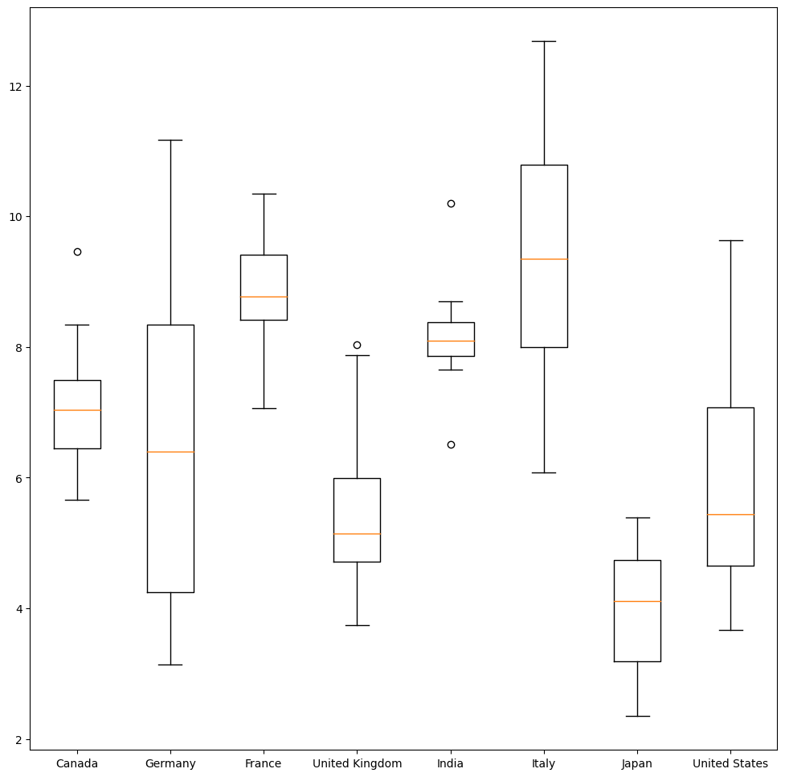

```python
plt.figure(figsize = (12, 12))
plt.boxplot(unemploymentg7df.T)
plt.xticks([1, 2, 3, 4, 5, 6, 7, 8], unemploymentg7df.T.columns.tolist())
plt.show()
```

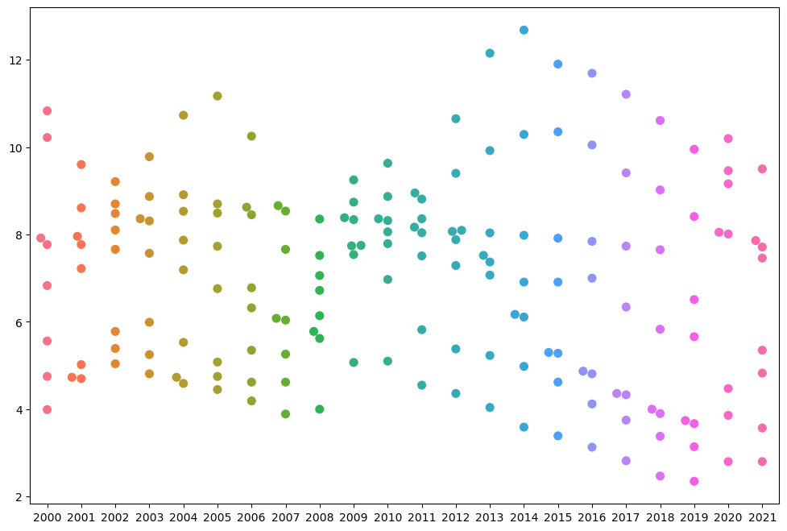

```python
plt.figure(figsize=(12, 8))
sns.swarmplot(data=unemploymentg7df, size=8)
plt.show()
```

Line Graph showing & Comparing the growths and dips of all the 8 Countries for unemployment over the years

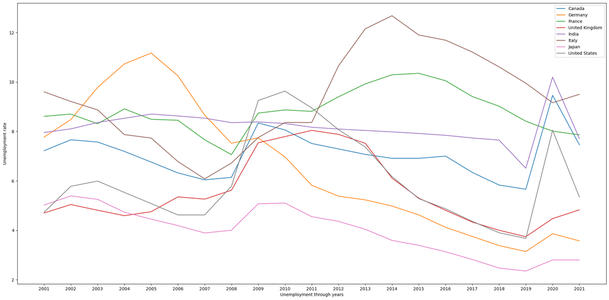

```python
fig, ax = plt.subplots(figsize = (25, 12))

for index, row in unemploymentg7df.iloc[:, 1:].iterrows():
    ax.plot(row.index, row.values, label = index)

ax.set_xlabel('Unemployment through years')
ax.set_ylabel('Unemployment rate')
ax.legend()

plt.show()
```

Variability in crime rates using violin plot

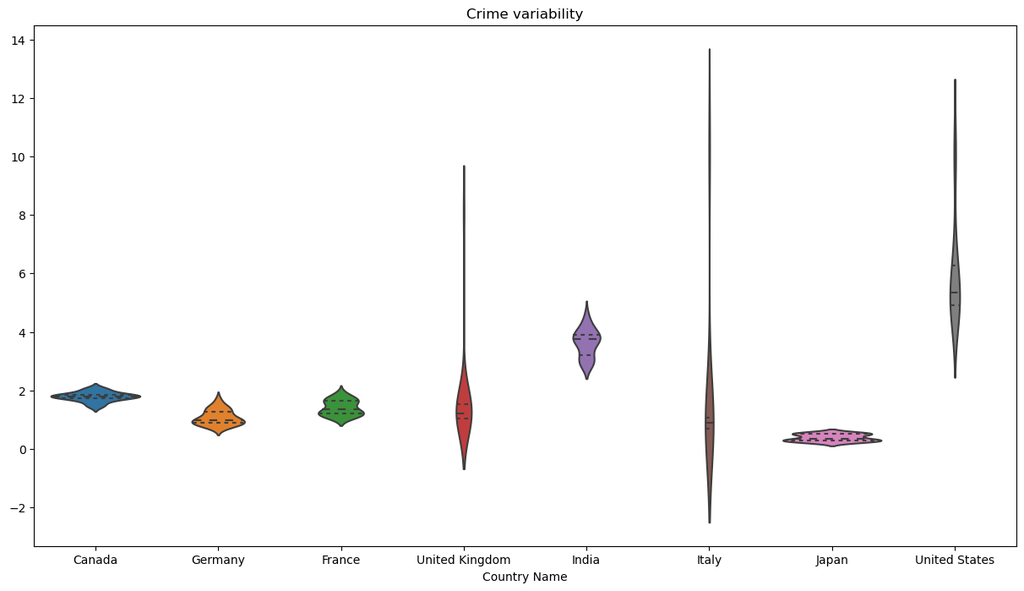

```python
plt.figure(figsize=(15, 8))
sns.violinplot(data=crimeg7df.T, inner='quartile')
plt.title('Crime variability')
plt.show()
```

Crime rate through the years using heatmap

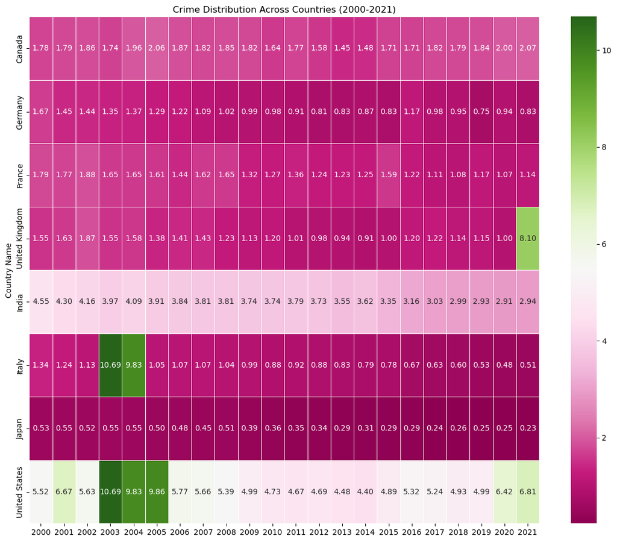

```python
plt.figure(figsize = (15, 12))
sns.heatmap(crimeg7df, cmap='PiYG', annot=True, fmt=".2f", linewidths=.5)
plt.title('Crime Distribution Across Countries (2000-2021)')
plt.show()
```

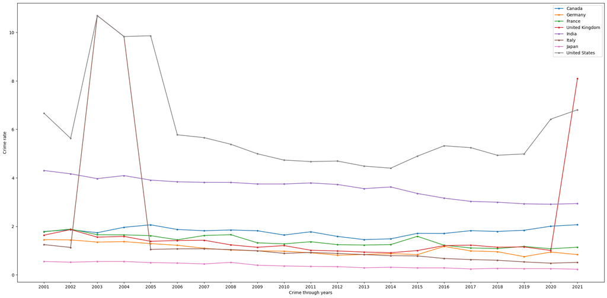

```python
# crime rate over the years
fig, ax = plt.subplots(figsize = (25, 12))

for index, row in crimeg7df.iloc[:, 1:].iterrows():
    ax.plot(row.index, row.values, label = index, marker = '.')

ax.set_xlabel('Crime through years')
ax.set_ylabel('Crime rate')
ax.legend()

plt.show()
```

# 8.Results (Correlation Analysis)

To get the correlation between the unemployment and crime data, the following charts are created by combining the above charts. Compare different countries unemployment and crime rates (Year wise)

```python
unemploymentg7df.T
```

| Country Name | Canada | Germany | France | United Kingdom | India | Italy | Japan | United States |
| --- | --- | --- | --- | --- | --- | --- | --- | --- |
| 2000 | 6.83 | 7.92 | 10.22 | 5.560 | 7.770 | 10.83 | 4.75 | 3.99 |
| 2001 | 7.22 | 7.77 | 8.61 | 4.700 | 7.957 | 9.60 | 5.02 | 4.73 |
| 2002 | 7.66 | 8.48 | 8.70 | 5.040 | 8.102 | 9.21 | 5.39 | 5.78 |
| 2003 | 7.57 | 9.78 | 8.31 | 4.810 | 8.360 | 8.87 | 5.25 | 5.99 |
| 2004 | 7.19 | 10.73 | 8.91 | 4.590 | 8.531 | 7.87 | 4.73 | 5.53 |
| 2005 | 6.76 | 11.17 | 8.49 | 4.750 | 8.700 | 7.73 | 4.45 | 5.08 |
| 2006 | 6.32 | 10.25 | 8.45 | 5.350 | 8.625 | 6.78 | 4.19 | 4.62 |
| 2007 | 6.04 | 8.66 | 7.66 | 5.260 | 8.536 | 6.08 | 3.89 | 4.62 |
| 2008 | 6.14 | 7.52 | 7.06 | 5.620 | 8.354 | 6.72 | 4.00 | 5.78 |
| 2009 | 8.34 | 7.74 | 8.74 | 7.540 | 8.384 | 7.75 | 5.07 | 9.25 |
| 2010 | 8.06 | 6.97 | 8.87 | 7.790 | 8.319 | 8.36 | 5.10 | 9.63 |
| 2011 | 7.51 | 5.82 | 8.81 | 8.040 | 8.168 | 8.36 | 4.55 | 8.95 |
| 2012 | 7.29 | 5.38 | 9.40 | 7.880 | 8.095 | 10.65 | 4.36 | 8.07 |
| 2013 | 7.07 | 5.23 | 9.92 | 7.520 | 8.037 | 12.15 | 4.04 | 7.37 |
| 2014 | 6.91 | 4.98 | 10.29 | 6.110 | 7.981 | 12.68 | 3.59 | 6.17 |
| 2015 | 6.91 | 4.62 | 10.35 | 5.300 | 7.915 | 11.90 | 3.39 | 5.28 |
| 2016 | 7.00 | 4.12 | 10.05 | 4.810 | 7.842 | 11.69 | 3.13 | 4.87 |
| 2017 | 6.34 | 3.75 | 9.41 | 4.330 | 7.733 | 11.21 | 2.82 | 4.36 |
| 2018 | 5.83 | 3.38 | 9.02 | 4.000 | 7.650 | 10.61 | 2.47 | 3.90 |
| 2019 | 5.66 | 3.14 | 8.41 | 3.740 | 6.510 | 9.95 | 2.35 | 3.67 |
| 2020 | 9.46 | 3.86 | 8.01 | 4.472 | 10.195 | 9.16 | 2.80 | 8.05 |
| 2021 | 7.46 | 3.57 | 7.86 | 4.826 | 7.713 | 9.50 | 2.80 | 5.35 |

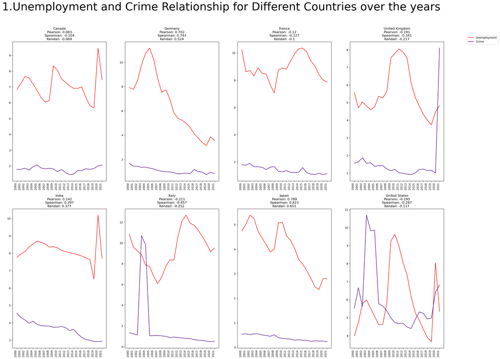

```python
fig, axes = plt.subplots(nrows=2, ncols=4, figsize=(28, 20))
c = 0

for i in range(2):  # Loop over rows
    for j in range(4):  # Loop over columns
        if c < 8:
            axes[i, j].plot(unemploymentg7df.T.iloc[:,c], label='Unemployment', color = "red")
            axes[i, j].plot(crimeg7df.T.iloc[:, c], label='Crime', color = "indigo")

            correlation_value = unemploymentg7df.T.iloc[:,c].corr(crimeg7df.T.iloc[:, c])
            correlation_value = round(correlation_value, 3)

            correlation_value_s = unemploymentg7df.T.iloc[:,c].corr(crimeg7df.T.iloc[:, c], method = 'spearman')
            correlation_value_s = round(correlation_value_s, 3)

            correlation_value_k = unemploymentg7df.T.iloc[:,c].corr(crimeg7df.T.iloc[:, c], method = 'kendall')
            correlation_value_k = round(correlation_value_k, 3)

            col_name = unemploymentg7df.T.columns[c]
            axes[i, j].set_title(f"{col_name}\nPearson: {correlation_value}\nSpearman: {correlation_value_s}\nKendall: {correlation_value_k}")
            axes[i, j].set_xticks(axes[i, j].get_xticks())
            axes[i, j].set_xticklabels(axes[i, j].get_xticklabels(), rotation=90, ha='right')
            c += 1
        else:
            axes[i, j].axis('off')

handles, labels = axes[0, 0].get_legend_handles_labels()
fig.legend(handles, labels,  bbox_to_anchor=(1, 0.9))
fig.suptitle('1.Unemployment and Crime Relationship for Different Countries over the years', fontsize=40)
plt.subplots_adjust(hspace=0.2)
plt.show()
```

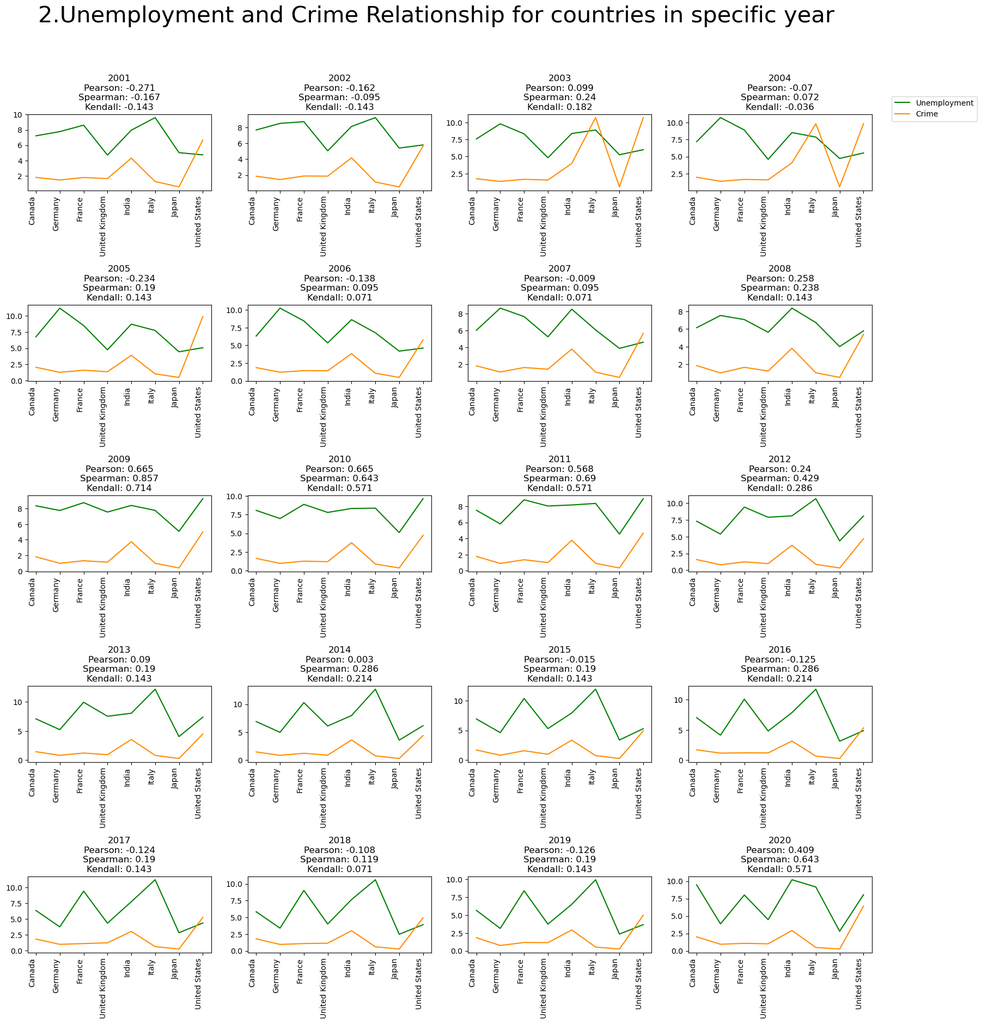

```python
fig, axes = plt.subplots(nrows=5, ncols=4, figsize=(20, 20))
c = 2001

for i in range(5):  # Loop over rows
    for j in range(4):  # Loop over columns
        if c < 2021:
            axes[i, j].plot(unemploymentg7df[str(c)], label='Unemployment', color = "green")
            axes[i, j].plot(crimeg7df[str(c)], label='Crime', color = "darkorange")

            correlation_value = unemploymentg7df[str(c)].corr(crimeg7df[str(c)])
            correlation_value = round(correlation_value, 3)

            correlation_value_s = unemploymentg7df[str(c)].corr(crimeg7df[str(c)], method = 'spearman')
            correlation_value_s = round(correlation_value_s, 3)

            correlation_value_k = unemploymentg7df[str(c)].corr(crimeg7df[str(c)], method = 'kendall')
            correlation_value_k = round(correlation_value_k, 3)

            axes[i, j].set_title(f"{c}\nPearson: {correlation_value}\nSpearman: {correlation_value_s}\nKendall: {correlation_value_k}")
            axes[i, j].set_xticks(axes[i, j].get_xticks())
            axes[i, j].set_xticklabels(axes[i, j].get_xticklabels(), rotation=90, ha='right')
            c += 1
        else:
            axes[i, j].axis('off')

handles, labels = axes[0, 0].get_legend_handles_labels()
fig.legend(handles, labels,  bbox_to_anchor=(1, 0.9))
fig.suptitle('2.Unemployment and Crime Relationship for countries in specific year', fontsize=30)
plt.subplots_adjust(hspace=1.5)
plt.show()
```

# 9.Conclusions:

**Summary of the plots**

**Correlation**

1. From Unemployment and Crime Relationship for Different Countries over the years we conclude that

   i) Germany and Japan: High Positive Linear Correlation

The data for Germany and Japan indicates a high Pearson correlation, suggesting a strong positive linear relationship between crime and unemployment over the years. This implies that as unemployment rates increase, there is a tendency for crime rates to also rise significantly in these countries.

ii)UK, India, Italy: Moderate Spearman Correlation

In the case of the UK, India, and Italy, the moderate Spearman correlation implies a moderate, nonlinear relationship between crime and unemployment. While not as strongly linear as in Germany and Japan, there is still a discernible connection, indicating that changes in unemployment may moderately influence crime rates in these countries.

iii) Canada, France, US: Less Correlation

For Canada, France, and the United States, there is less correlation between crime and unemployment. This suggests that the fluctuations in unemployment rates may not be closely tied to changes in crime rates in these countries. Other factors, such as social policies, law enforcement strategies, or economic conditions, may have a more significant impact on crime rates compared to unemployment.

ii) Weak Relationship (2001-2008, 2013-2019): Weak Correlation

In contrast, for the years 2001 to 2008 and 2013 to 2019, the relationship between unemployment and crime is characterized by a weak correlation. This suggests that during these years, the fluctuations in unemployment rates are not strongly or consistently linked to changes in crime rates. Other factors, such as social policies, law enforcement strategies, or broader economic conditions, may have a more dominant impact on crime rates during these periods.

1. Paradoxically, low unemployment rates can disguise substantial poverty in a country, while high unemployment rates can occur in countries with a high level of economic development and low rates of poverty.

# 10.Limitations and Future works

Addressing the limitations and exploring future avenues for research will enhance the depth and applicability of the findings regarding the relationship between unemployment and crime. This could lead to more informed policy recommendations and a better understanding of the complex dynamics at play.

Limitations

1. Causation vs. Correlation: Correlation does not imply causation. Even if a correlation exists between unemployment and crime, it does not necessarily mean that one directly causes the other. There may be confounding variables or underlying factors that contribute to both.
1. Data quality and accuracy : The reliability of the conclusions heavily relies on the accuracy and quality of the data used. Incomplete or inaccurate data could lead to skewed results and misinterpretations.

For unemployment data following factors were not taken into account:

1. Employment and unemployment due to seasonal unemployment nature eg. in agriculture etc. was not taken into account
2. Many Women are often responsible for the care of children and the elderly and for household affairs and also due to social, cultural descrimination and thus mainly are not registered as unemployed.
3. There may be also persons not currently in the labour market who want to work but do not actively "seek" work because they view job opportunities as limited, or because they have restricted labour mobility, or face discrimination, or structural, social or cultural barriers.

For crime data following factors were not taken into account:

1. An analysis of official reports and research literature is regularly carried out to verify homicide data used by government agencies and the scientific community. As a result of the data collection and validation process, in many countries several homicide datasets have become available from different or multiple sources and thus can led to different results
2. The degree to which different societies apportion the level of culpability to acts resulting in death is also subject to variation.
1. Lack of Granularity: The study may lack granularity in examining specific types of crime or nuances in the labor market. Different crimes may have varied relationships with unemployment, and diverse job sectors may respond differently to economic changes.
2. Regional Variations: The analysis might overlook regional variations within countries. Different regions may experience distinct economic and social conditions that impact the relationship between unemployment and crime differently.

Future works:

1. Multifactorial Analysis: The simultaneous impact of multiple factors, such as social policies, education, and economic conditions, on crime rates can be investigated. Understanding the interplay of these factors can contribute to a more nuanced analysis.
2. Policy Evaluation: The impact of different social and economic policies on the relationship between unemployment and crime can be evaluated. This can inform policymakers about effective strategies for crime prevention and economic stability.
3. Machine Learning Approaches: Machine learning algorithms can be appllied to uncover non-linear patterns and interactions within the data. Techniques like regression trees, random forests, or neural networks may reveal complex relationships not captured by traditional statistical methods.